# NFL 2020 Week 9

MAJ Daniel Baller

8/27/2019

## Instructor Group Predictions

This Week's Predictions

Week 9

| Game | Prediction | Winner | Correct | Correct Votes | Correct Percent |
| --- | --- | --- | --- | --- | --- |
| 1 | Green Bay Packers | Green Bay Packers | Yes | 16 | 0.8889 |
| 2 | Minnesota Vikings | Minnesota Vikings | Yes | 12 | 0.6667 |
| 3 | Denver Broncos | Atlanta Falcons | No | 8 | 0.4444 |
| 4 | Houston Texans | Houston Texans | Yes | 12 | 0.6667 |
| 5 | Washington Football Team | New York Giants | No | 6 | 0.3333 |
| 6 | Seattle Seahawks | Buffalo Bills | No | 5 | 0.2778 |
| 7 | Tennessee Titans | Tennessee Titans | Yes | 12 | 0.6667 |
| 8 | Kansas City Chiefs | Kansas City Chiefs | Yes | 18 | 1.0000 |
| 9 | Baltimore Ravens | Baltimore Ravens | Yes | 12 | 0.6667 |
| 10 | Las Vegas Raiders | Las Vegas Raiders | Yes | 15 | 0.8333 |
| 11 | Arizona Cardinals | Miami Dolphins | No | 2 | 0.1111 |
| 12 | Pittsburgh Steelers | Pittsburgh Steelers | Yes | 18 | 1.0000 |
| 13 | Tampa Bay Buccaneers | New Orleans Saints | No | 2 | 0.1111 |
| 14 | New England Patriots | New England Patriots | Yes | 17 | 0.9444 |

Our win percentage for the week is 0.6429

Our season win percentage so far is 0.6591

Games picked this season 132

Correct Games this season 87

predictions this week

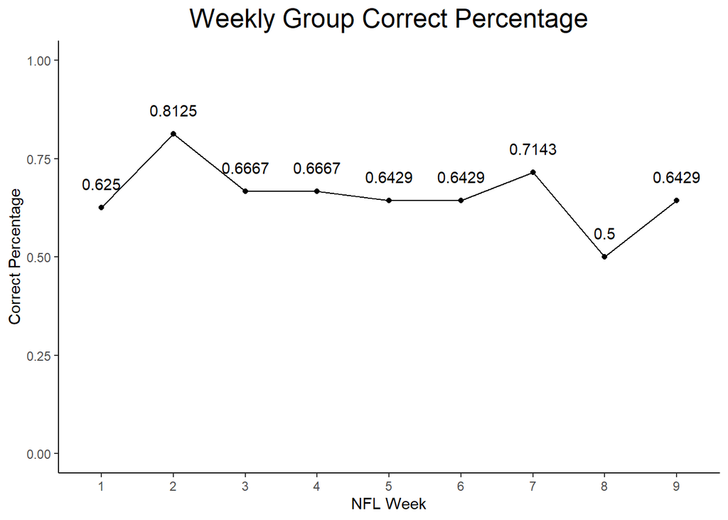

## Individual Predictions

Individual Results

Week 9

Name

Weekly # Correct

Percent

Weeks Picked

Season Percent

Adj Season Percent

Season Trend

Week 1

Week 2

Week 3

Week 4

Week 5

Week 6

Week 7

Week 8

Week 9

Shane Clark

10

14

9

9

9

9

10

NA

11

0.7857

8

0.6864

0.6101

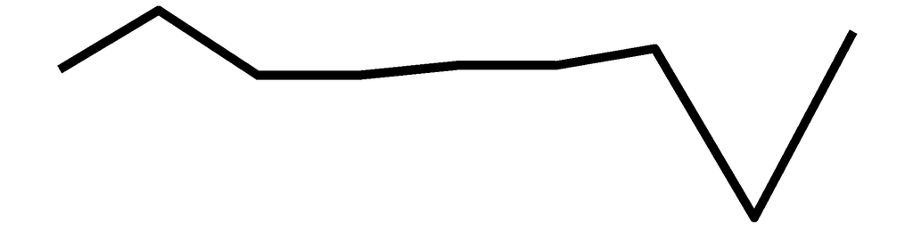

Daniel Baller

11

10

10

9

9

5

8

9

11

0.7857

9

0.6212

0.6212

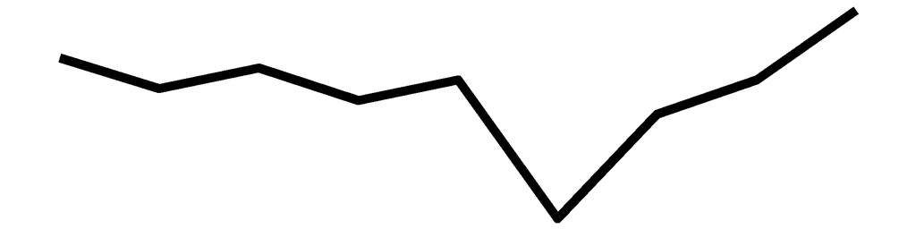

Frank Czerniakowski

7

13

10

9

8

6

9

6

11

0.7857

9

0.5985

0.5985

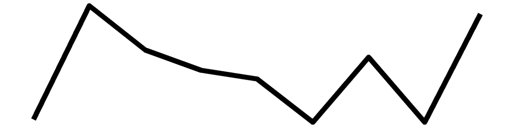

James Starling

15

12

9

12

10

NA

11

8

10

0.7143

8

0.7373

0.6554

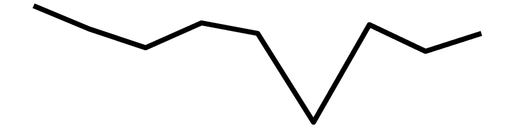

Gregory Minetos

9

14

10

12

8

8

12

7

10

0.7143

9

0.6818

0.6818

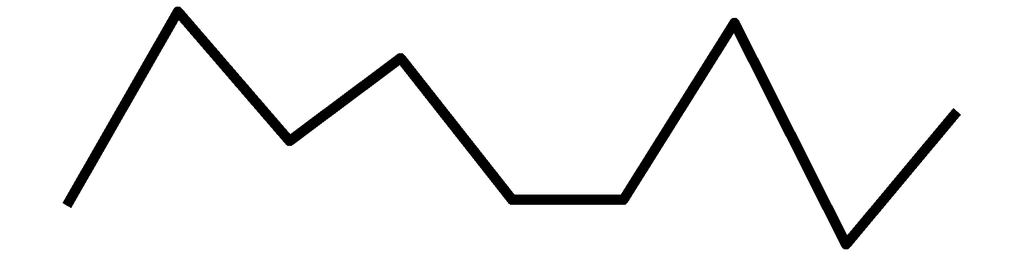

Kevin Cummiskey

13

11

9

9

10

7

9

5

10

0.7143

9

0.6288

0.6288

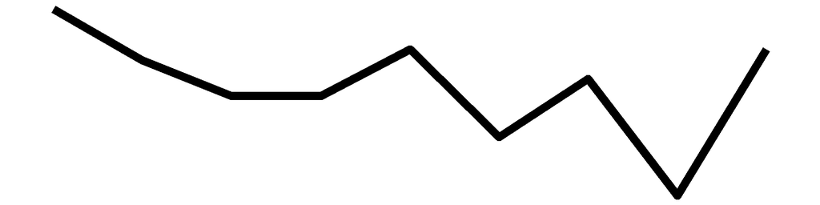

Nicholas Reisweber

9

10

10

8

10

7

8

8

10

0.7143

9

0.6061

0.6061

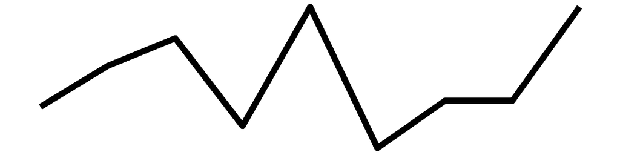

Gabriel Costa

9

12

6

9

10

7

9

7

10

0.7143

9

0.5985

0.5985

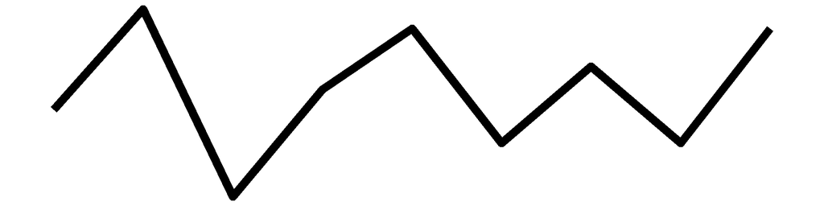

Margaret Wieczorek

11

14

9

9

8

NA

10

8

9

0.6429

8

0.6610

0.5876

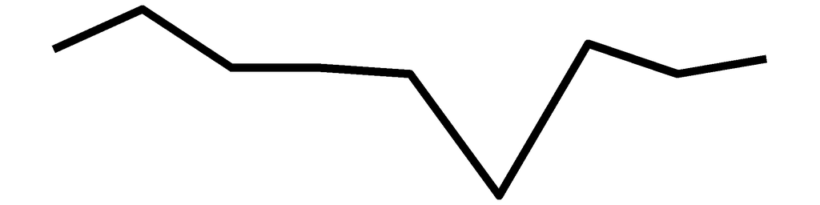

James Pleuss

9

12

10

12

7

8

10

9

9

0.6429

9

0.6515

0.6515

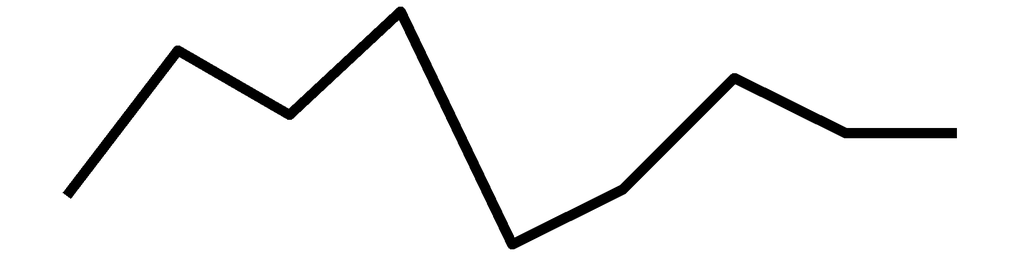

Michael Prokos

9

12

9

8

11

10

9

7

9

0.6429

9

0.6364

0.6364

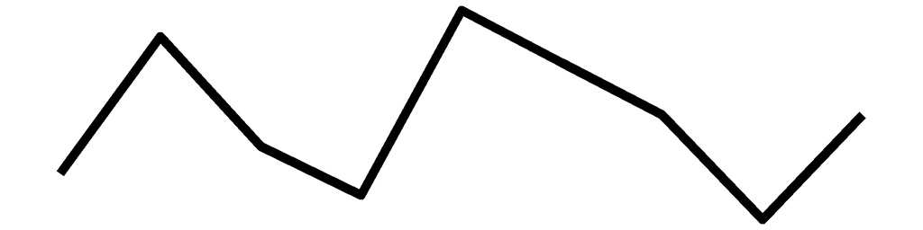

John Kearby

9

11

6

9

9

8

12

6

9

0.6429

9

0.5985

0.5985

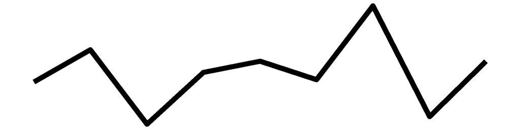

Kevin Quigley

8

8

9

10

10

8

8

6

8

0.5714

9

0.5682

0.5682

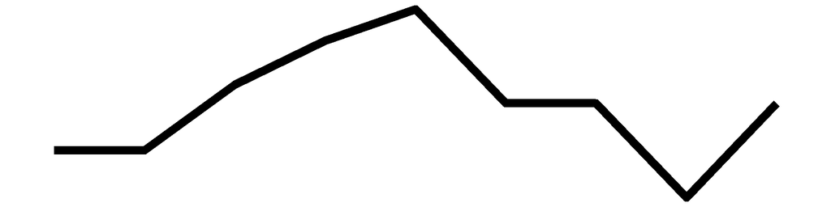

Timothy Moore

10

11

8

9

7

9

7

7

7

0.5000

9

0.5682

0.5682

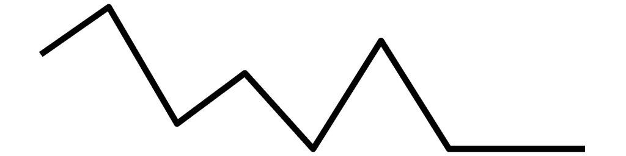

Eric Swenson

4

8

10

9

9

8

9

8

7

0.5000

9

0.5455

0.5455

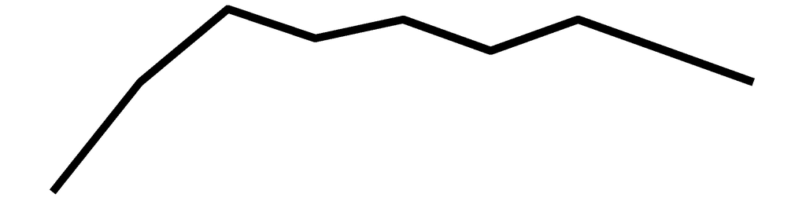

Josephine Cammack

9

11

12

10

9

9

11

7

6

0.4286

9

0.6364

0.6364

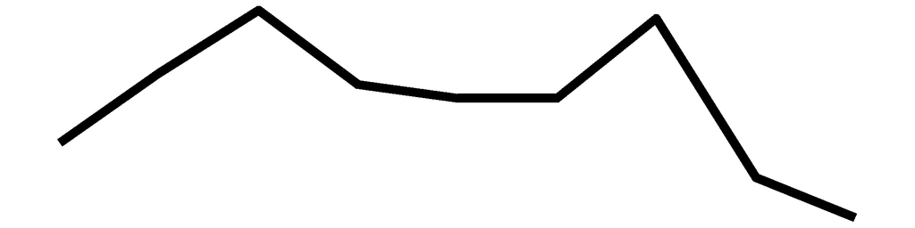

Blake Schwartz

10

9

10

10

10

9

9

6

5

0.3571

9

0.5909

0.5909

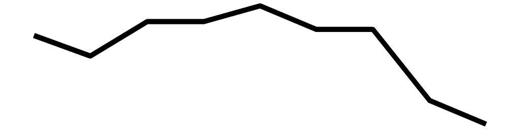

Tina Hartley

9

11

10

8

8

9

9

7

3

0.2143

9

0.5606

0.5606

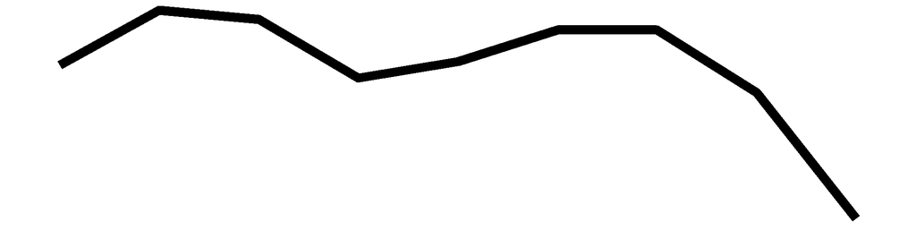

Daniel Richardson

13

11

10

10

8

NA

8

NA

NA

0.0000

6

0.6667

0.4445

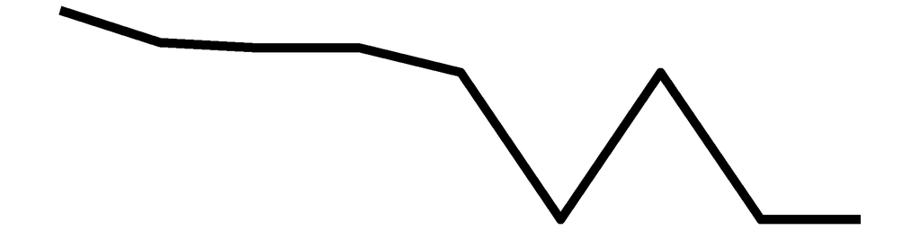

Welvin Lucero

9

11

9

10

NA

NA

11

8

NA

0.0000

6

0.6444

0.4296

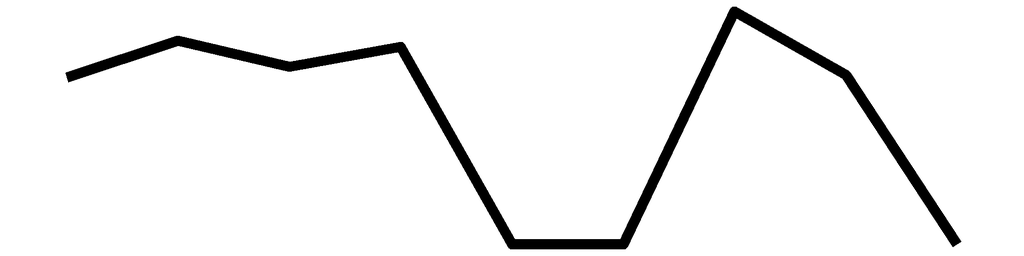

Travis Russell

11

8

8

11

10

10

10

8

NA

0.0000

8

0.6441

0.5725

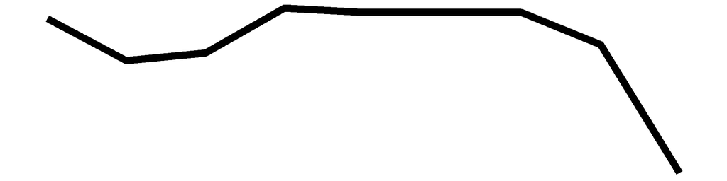

Andrew Lee

9

10

8

NA

NA

NA

NA

NA

NA

0.0000

3

0.5745

0.1915

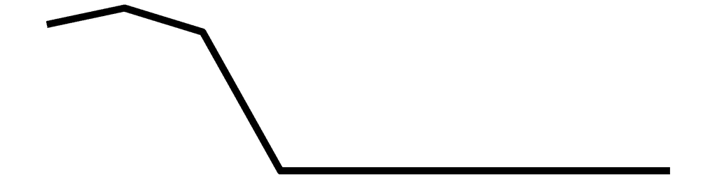

Congrats Shane Clark for having the best picks this week, with a correct percentage of 0.7857, Congrats Daniel Baller for having the best picks this week, with a correct percentage of 0.7857, Congrats Frank Czerniakowski for having the best picks this week, with a correct percentage of 0.7857

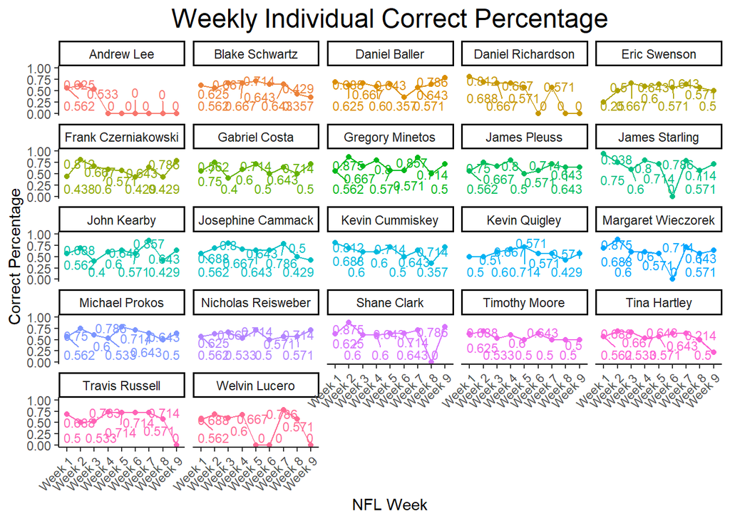

## MA206 Group Predictions

This Week's MA206 Predictions

Week 9

| Game | Prediction | Winner | Correct | Correct Votes | Correct Percent |
| --- | --- | --- | --- | --- | --- |
| 1 | Green Bay Packers | Green Bay Packers | Yes | 12 | 0.8571 |
| 2 | Detroit Lions | Minnesota Vikings | No | 5 | 0.3571 |
| 3 | Denver Broncos | Atlanta Falcons | No | 5 | 0.3571 |
| 4 | Tie | Houston Texans | -- | 7 | 0.5000 |
| 5 | Tie | New York Giants | -- | 7 | 0.5000 |
| 6 | Seattle Seahawks | Buffalo Bills | No | 2 | 0.1429 |
| 7 | Tennessee Titans | Tennessee Titans | Yes | 8 | 0.5714 |
| 8 | Kansas City Chiefs | Kansas City Chiefs | Yes | 14 | 1.0000 |
| 9 | Baltimore Ravens | Baltimore Ravens | Yes | 11 | 0.7857 |
| 10 | Las Vegas Raiders | Las Vegas Raiders | Yes | 13 | 0.9286 |
| 11 | Arizona Cardinals | Miami Dolphins | No | 5 | 0.3571 |
| 12 | Pittsburgh Steelers | Pittsburgh Steelers | Yes | 13 | 0.9286 |
| 13 | Tampa Bay Buccaneers | New Orleans Saints | No | 4 | 0.2857 |
| 14 | New England Patriots | New England Patriots | Yes | 14 | 1.0000 |

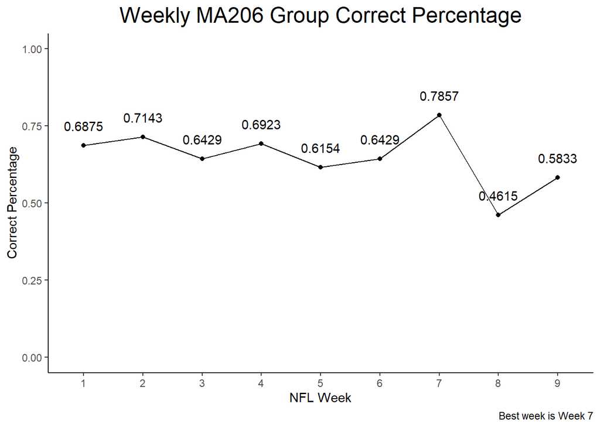

# Cadet Individual Results

MA206 Individual Results

Week 9

Name

Weekly # Correct

Percent

Weeks Picked

Season Percent

Adj Season Percent

Season Trend

Week 1

Week 2

Week 3

Week 4

Week 5

Week 6

Week 7

Week 8

Week 9

Sidney Cash

10

10

NA

10

NA

8

8

7

11

0.7857

7

0.6214

0.4833

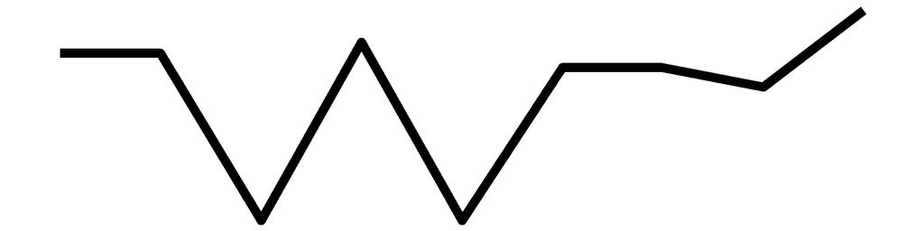

Laurence Dowd

10

10

10

9

10

NA

12

NA

10

0.7143

7

0.6827

0.5310

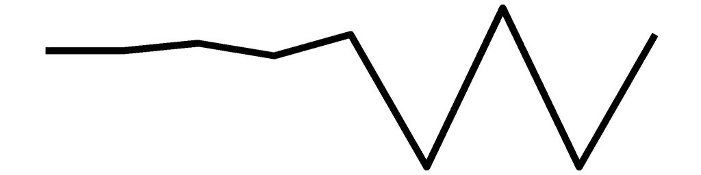

Thomas Bizub

10

14

8

11

8

9

10

8

10

0.7143

9

0.6667

0.6667

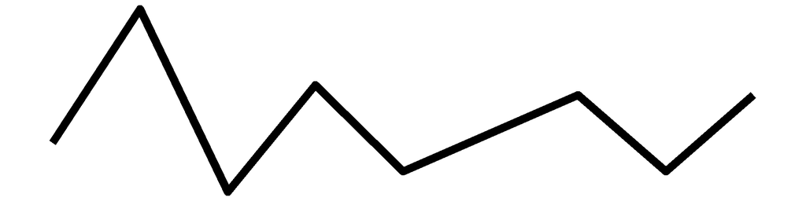

Christopher Erb

9

9

7

11

9

11

8

11

10

0.7143

9

0.6439

0.6439

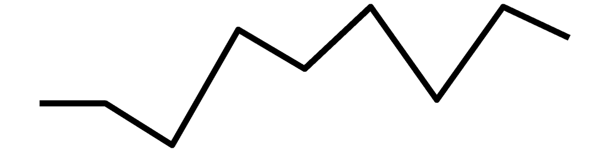

Joshua Loyd

11

9

8

NA

6

9

NA

6

10

0.7143

7

0.5728

0.4455

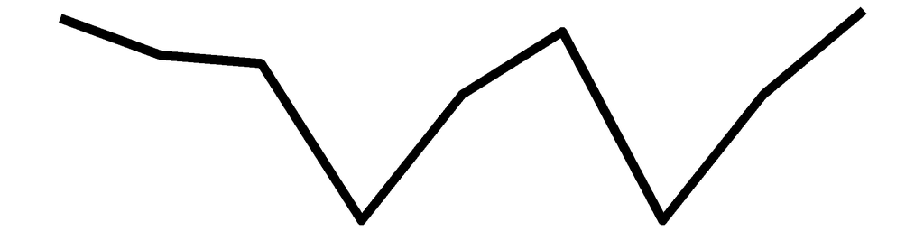

John White

10

11

10

8

12

9

11

6

9

0.6429

9

0.6515

0.6515

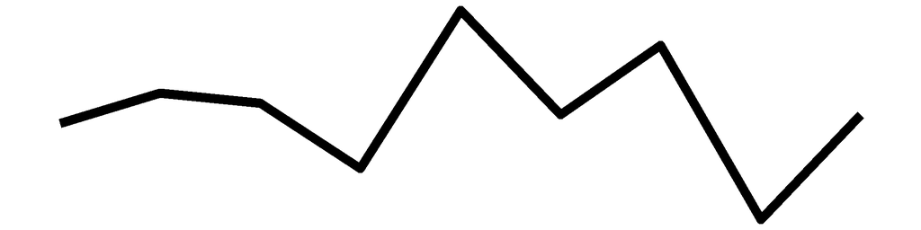

Zakai Bufkin

8

11

7

9

8

10

9

7

9

0.6429

9

0.5909

0.5909

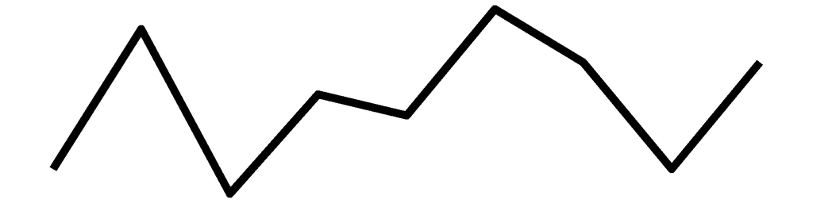

Jay Hajost

11

7

10

NA

6

NA

NA

7

9

0.6429

6

0.5618

0.3745

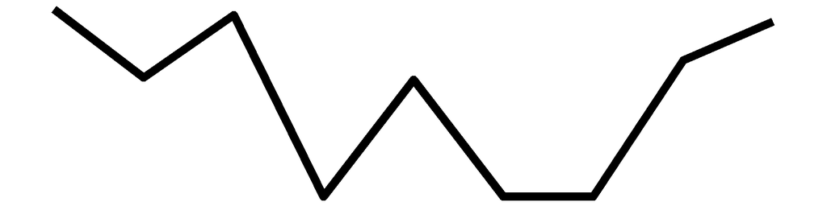

Jonathan Kemp

10

10

NA

NA

11

10

11

7

8

0.5714

7

0.6569

0.5109

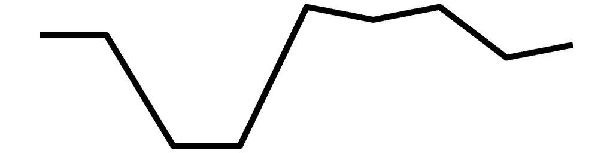

Caroline Swenson

8

12

11

13

7

8

10

NA

8

0.5714

8

0.6525

0.5800

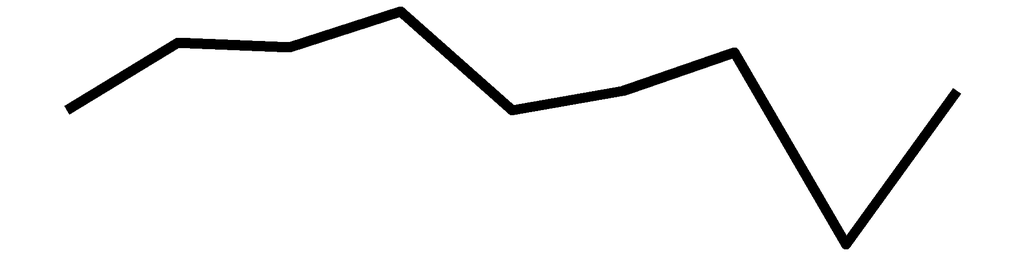

Sydney Shannon

10

9

8

9

8

7

9

5

8

0.5714

9

0.5530

0.5530

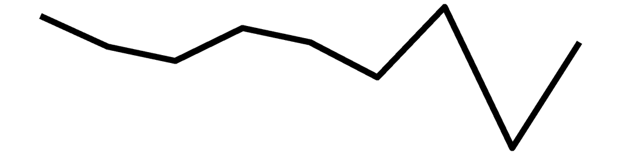

Victor Olawale-Apanpa

8

NA

10

NA

10

NA

10

7

7

0.5000

6

0.5977

0.3985

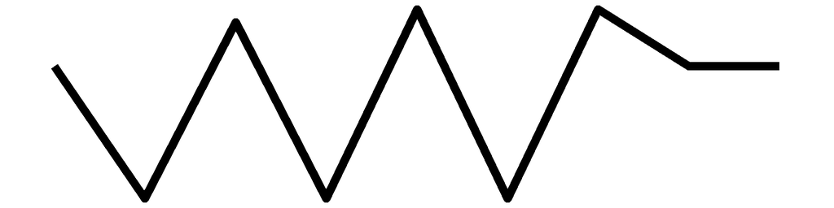

Paige Lennon

NA

NA

NA

11

10

8

11

8

6

0.4286

6

0.6353

0.4235

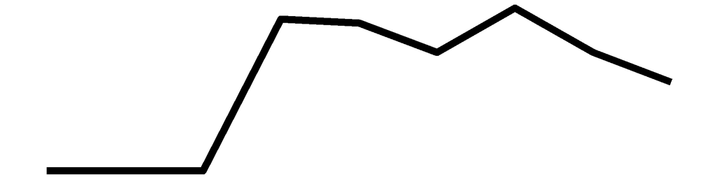

Joshua Gilliard

9

8

9

10

10

7

10

7

5

0.3571

9

0.5682

0.5682

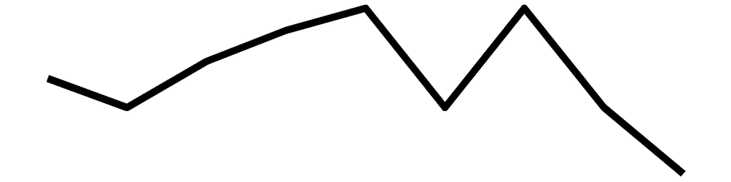

Kieran Place

12

11

8

NA

10

10

9

NA

NA

0.0000

6

0.6742

0.4495

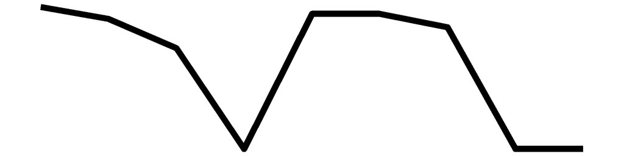

Luca Testa

NA

NA

10

NA

NA

NA

NA

NA

NA

0.0000

1

0.6667

0.0741

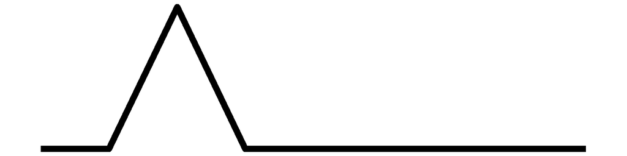

Cameron Patterson

11

9

8

NA

NA

NA

NA

NA

NA

0.0000

3

0.5957

0.1986

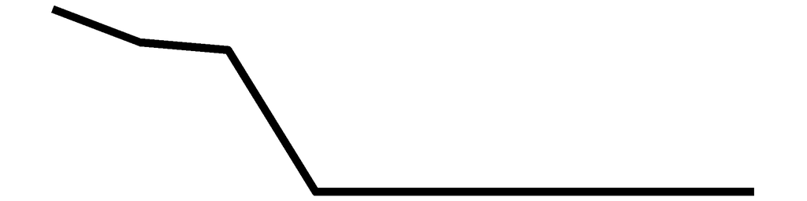

Gabriela Peralta

11

8

9

NA

8

8

10

6

NA

0.0000

7

0.5825

0.4531

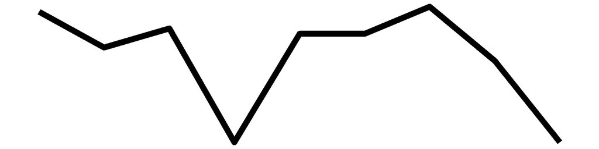

Ryan Jackovic

11

10

NA

7

7

8

8

7

NA

0.0000

7

0.5631

0.4380

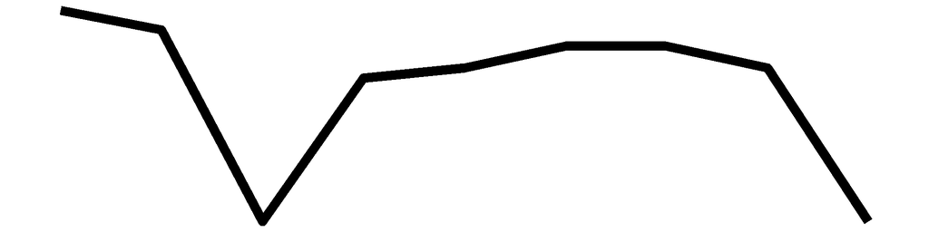

Amadou Bah

9

NA

NA

NA

NA

NA

NA

NA

NA

0.0000

1

0.5625

0.0625

Margaret Williams

9

NA

NA

NA

NA

NA

NA

NA

NA

0.0000

1

0.5625

0.0625

Logan Kauina

9

NA

NA

NA

NA

NA

NA

NA

NA

0.0000

1

0.5625

0.0625

Caleb John

NA

9

NA

NA

NA

NA

NA

NA

NA

0.0000

1

0.5625

0.0625

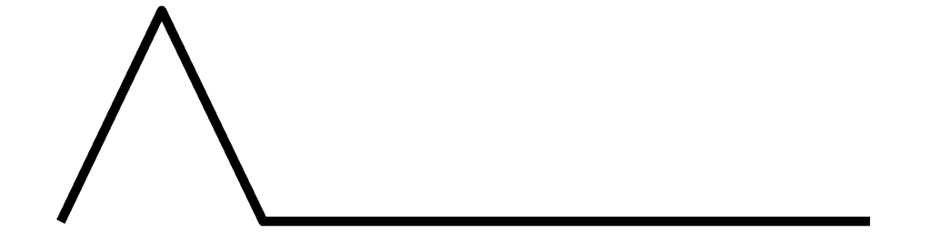

August Rannow

9

NA

NA

NA

7

NA

NA

NA

NA

0.0000

2

0.5333

0.1185

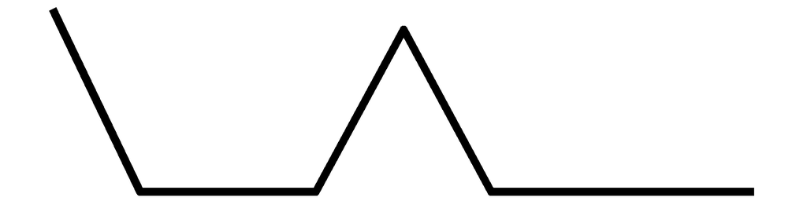

Peter Digenan

9

6

8

10

7

NA

NA

NA

NA

0.0000

5

0.5263

0.2924

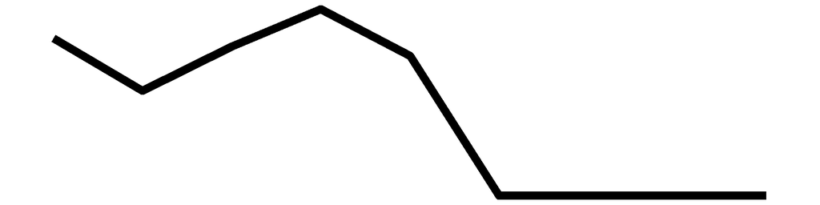

Caleb Doyle

9

NA

NA

NA

NA

NA

NA

6

NA

0.0000

2

0.5000

0.1111

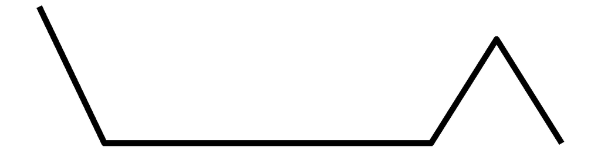

Sydney Johnson

NA

NA

NA

NA

NA

NA

NA

6

NA

0.0000

1

0.4286

0.0476

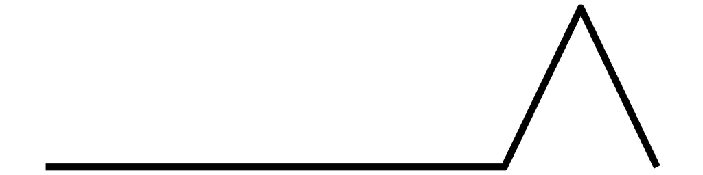

Congrats Sidney Cash for having the best cadet picks this week, with a correct percentage of 0.7857

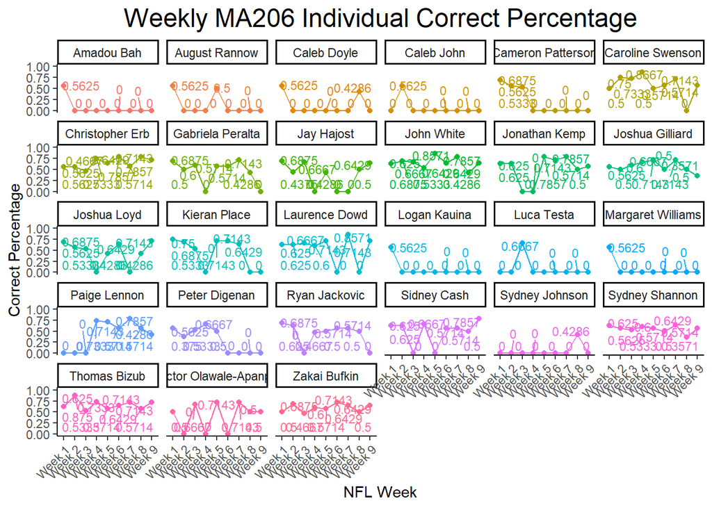

## Combined cadet and instructor prediction

This Week's Combined Cadet and Instructor Predictions

Week 9

| Game | Prediction | Winner | Correct | Correct Votes | Correct Percent |
| --- | --- | --- | --- | --- | --- |
| 1 | Green Bay Packers | Green Bay Packers | Yes | 28 | 0.8750 |
| 2 | Minnesota Vikings | Minnesota Vikings | Yes | 17 | 0.5312 |
| 3 | Denver Broncos | Atlanta Falcons | No | 13 | 0.4062 |
| 4 | Houston Texans | Houston Texans | Yes | 19 | 0.5938 |
| 5 | Washington Football Team | New York Giants | No | 13 | 0.4062 |
| 6 | Seattle Seahawks | Buffalo Bills | No | 7 | 0.2188 |
| 7 | Tennessee Titans | Tennessee Titans | Yes | 20 | 0.6250 |
| 8 | Kansas City Chiefs | Kansas City Chiefs | Yes | 32 | 1.0000 |
| 9 | Baltimore Ravens | Baltimore Ravens | Yes | 23 | 0.7188 |
| 10 | Las Vegas Raiders | Las Vegas Raiders | Yes | 28 | 0.8750 |
| 11 | Arizona Cardinals | Miami Dolphins | No | 7 | 0.2188 |
| 12 | Pittsburgh Steelers | Pittsburgh Steelers | Yes | 31 | 0.9688 |
| 13 | Tampa Bay Buccaneers | New Orleans Saints | No | 6 | 0.1875 |
| 14 | New England Patriots | New England Patriots | Yes | 31 | 0.9688 |

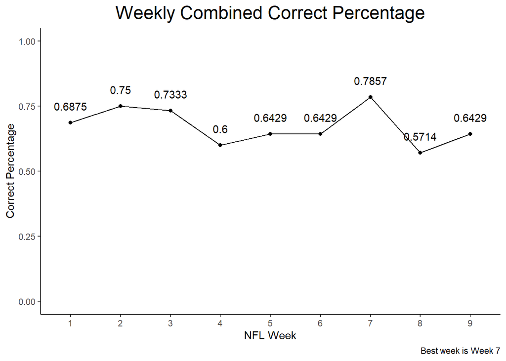

Our combined win percentage for the week is 0.6429

Our season combined win percentage so far is 0.6742

32 total predictions this week

This Week's Matched Cadet and Instructor Predictions

Week 9

| Game | Prediction | Correct |
| --- | --- | --- |
| 1 | Green Bay Packers | Yes |
| 2 | -- | -- |
| 3 | Denver Broncos | No |
| 4 | -- | -- |
| 5 | -- | -- |
| 6 | Seattle Seahawks | No |
| 7 | Tennessee Titans | Yes |
| 8 | Kansas City Chiefs | Yes |
| 9 | Baltimore Ravens | Yes |
| 10 | Las Vegas Raiders | Yes |
| 11 | Arizona Cardinals | No |
| 12 | Pittsburgh Steelers | Yes |
| 13 | Tampa Bay Buccaneers | No |
| 14 | New England Patriots | Yes |

[figure not shown]

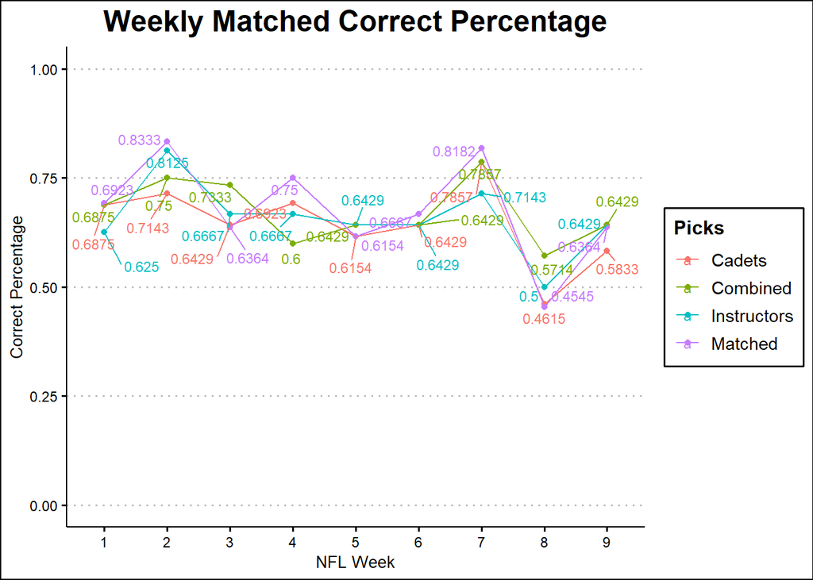

```r
group_season_for_plotting %>% add_column(Picks = "Instructors") %>%
  rbind(c_group_season_for_plotting %>% add_column(Picks = "Cadets")) %>%
  rbind(comb_season_for_plotting %>% add_column(Picks = "Combined")) %>%
  rbind(matched_season_percent_for_plotting %>% add_column(Picks = "Matched")) %>%
  ggplot(aes(x = as.factor(Week), y = `Win Percentage`, color = Picks))+
  geom_point()+
  geom_path(aes(x = Week))+
  geom_text_repel(aes(label=`Win Percentage`),hjust=0, vjust=0, size = 3)+
  #geom_text(aes(label=`Win Percentage`),hjust=.5, vjust=-1.5)+
  ylim(c(0, 1)) +
  labs(x = "NFL Week",
       y = "Correct Percentage",
       title = "Weekly Matched Correct Percentage")+
  theme_clean()+
  theme(plot.title = element_text(hjust = 0.5, size = 18),
        legend.position = "right")
```